# RaceReport

## Fantasy League Scores

Scores for drivers/constructors in the current year's fantasy league, along with manager/team points, values, and statistics. Note: driver and constructor values are taken as the cost to enter the current race and are updated the week before the race.

## Lineup Scores

After 239 races, Nico Hulkenberg gets his maiden podium finishes and tops the weekly scoreboard for Silverstone with a huge 48 points. Oscar Piastri and Lando Norris are a distant second and third with 38 and 37 points, respectively. Lewis Hamilton secures fourth place with 24, and Lance Stroll rounds out the top five with 22 points this week. Gabriel Bortoleto, Isack Hadjar, and Franco Colapinto take the honours at the bottom of the table with -20 points, followed closely by Liam Lawson with -18. Kimi Antonelli has another disappointing result with -7, ahead of Carlos Sainz with -1. Yuki Tsunoda rounds out the bottom five with a pointless weekend for Red Bull.

McLaren continue to dominate the constructors' table with another top score of 90 points. Red Bull and Ferrari are a distant joint second with 41 points, ahead of Aston Martin with 33. Racing Bulls suffer a huge -35 points loss, ahead of Alpine with 5. Kick Sauber round out the bottom three with 17 points.

Lando Norris holds on to his lead at the top with 425 points, ahead of teammate Piastri with 418 points. Max Verstappen is now a distant third with 294 points and falling into the clutches of George Russell in fourth with 271 points. Lewis Hamilton rounds out the top five with 217 points. Liam Lawson drops down to the bottom of the table with -8 points, ahead of Gabriel Bortoleto who returns to the negative alongside Colapinto with -2 points. Fernando Alonso is next with 7, ahead of Carlos Sainz with 9. Pierre Gasly rounds out the bottom five with 23 points.

McLaren are leaps ahead of the rest now, shooting above the 1000 points mark for the first time this season. They now sit on 1022 points ahead of Ferrari in second with 604. Mercedes are in third with 501 points. Alpine are at the bottom of the pack with 78 points, the only team not to hit triple figures. Aston Martin are next with 155 points, and Williams round out the bottom three with 160 points.

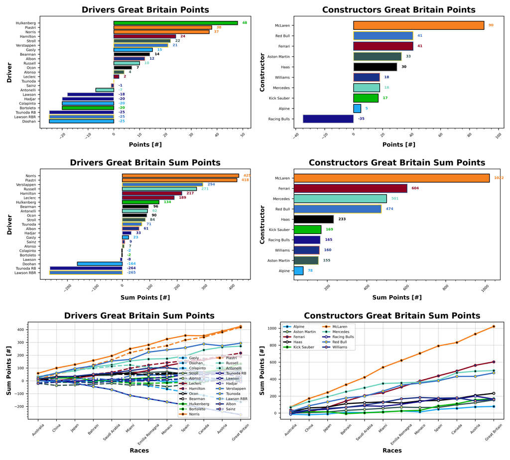

All values are in Million Dollars.

There are still only two drivers to keep 100% positive results this season, those being George Russell and Oscar Piastri. Interestingly, Colapinto has now reached the same level of inconsistency as Jack Doohan in a similar number of races. Red Bull, Mercedes, and McLaren continue their 100% record, with Alpine and Racing Bulls dropping down to a 2/3 consistency.

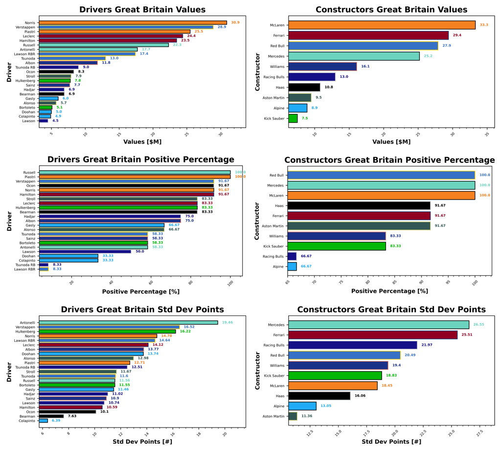

Mr Consistent, Colapinto, continues a reasonable grouping with 6.39 standard deviation. He's joined there by the two Haas drivers of Bearman and Ocon. The least consistent driver of the season so far is Kimi Antonelli, followed by Verstappen and then Hulkenberg. Aston Martin are your most consistent team of the season, with a standard deviation of 11.36, followed by Alpine and Haas. Mercedes and Ferrari are you least consistent of the year.

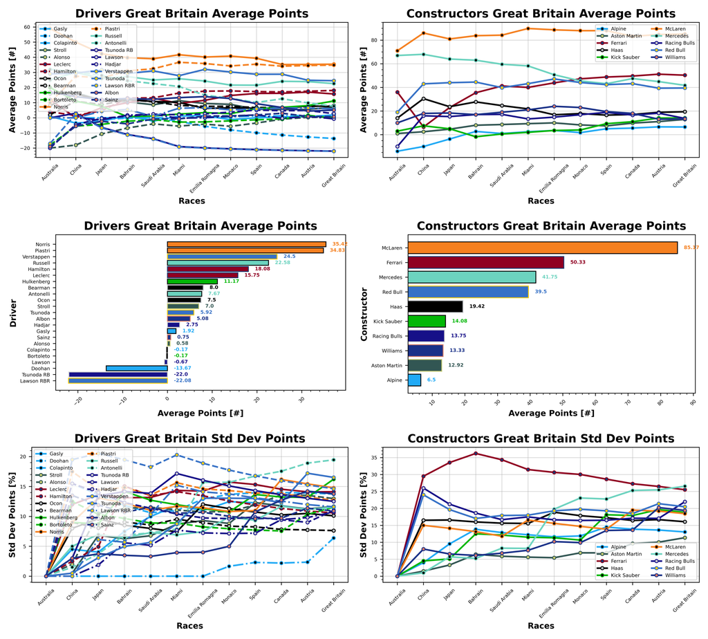

Another great weekend for Kick Sauber, with Nico Hulkenberg topping driver of the week with a huge points per value of 5.77 ppm. Lance Stroll is a distant second with 2.78 ppm, ahead of Pierre Gasly with 2.5 ppm. Oliver Bearman is in fourth with 2.03 ppm, and then it's Oscar Piastri, who brings home 1.49 ppm in fifth. Franco Colapinto was the worst driver of the weekend with -4.08 ppm, behind Liam Lawson with -4.0 ppm. Gabriel Bortoleto is in third with -3.92 ppm, behind Isack Hadjar with -2.9 ppm. Kimi Antonelli rounds out the bottom five with -0.9 ppm.

Aston Martin were your team of the week, with 3.47 ppm. McLaren come home in second with 2.7 ppm, ahead of Haas in third with 2.31 ppm. Racing Bulls were the worst team of the week with -2.69 ppm, behind Mercedes with 0.28 ppm. Alpine round out the bottom three with 0.56 ppm.

ppm = points per million Dollars.

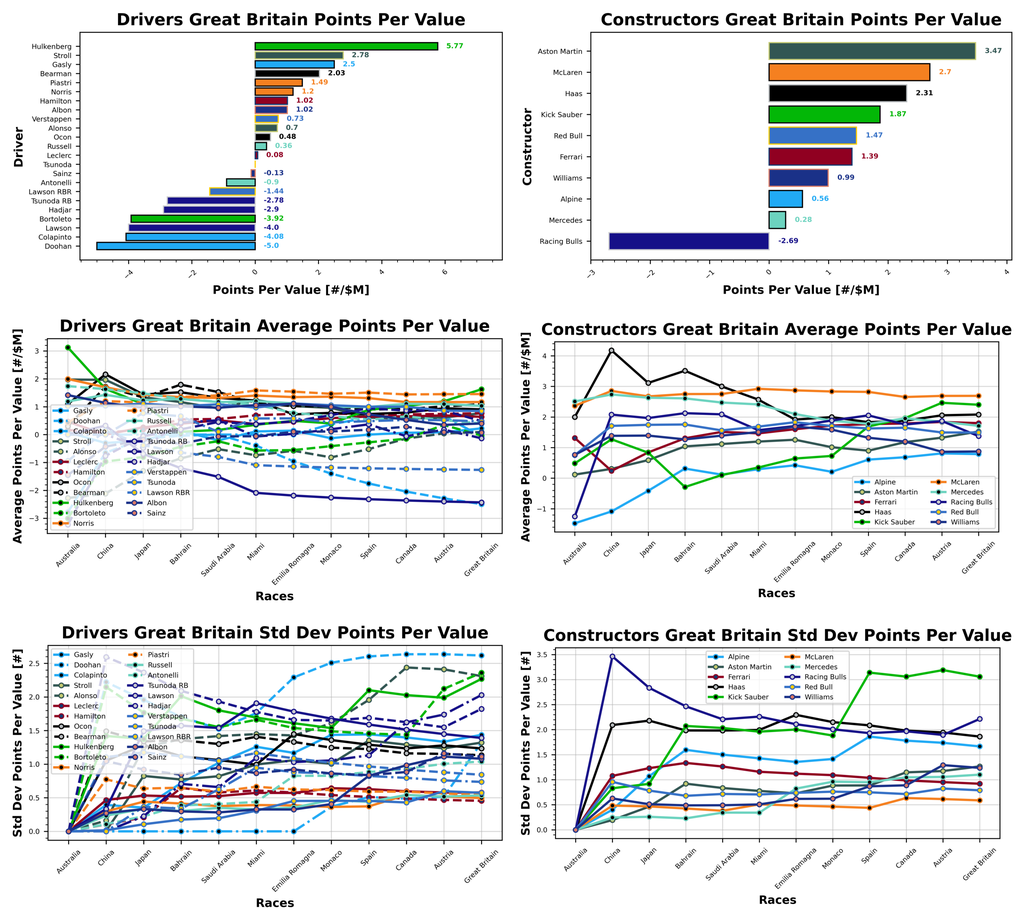

### Manager Scores

It's beginning to feel like 2024 all over again, but another week at the top for Stefanus and Syahrul with 250 points, ahead of Stefanus and Gelael with 241. Phil and BMW FTW are in third with 222 points, ahead of Stefanus and Haryanto with 214. Jake and Kick Sauber In The Audi with 193 points.

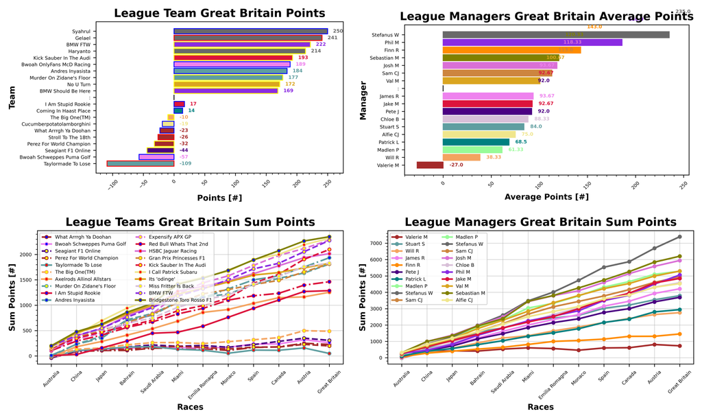

Stefanus and Syahrul hold onto their lead at the top with 2600 points, but it's now a 1-2-3 for Stefanus with Haryanto and Gelael close behind with 2407 and 2391 points. Sebastian drops to fourth with Bridgestone Toro Rosso F1 with 2350 points ahead of Alfie and I Call Patrick Subaru with 2318 points.

Stuart and Taylormade To Lose are still at the bottom with 49 points. Valerie and Perez For World Champion and What Arrrgh Ya Doohan are in second and third with 197 and 227 points ahead of James and Bwoah Schweppes Puma Golf with 263 points. Alfie and Cucumberpotatolamborghini are in fifth with 283 points.

Our biggest winner this week was Phil whose teams BMW Should Be Here and BMW Motorrad both gain 4 places. Our biggest losers were Jake and Madlen whose teams I Am Stupid Rookie and Push, Push - Box Now Too both lose 4 places.

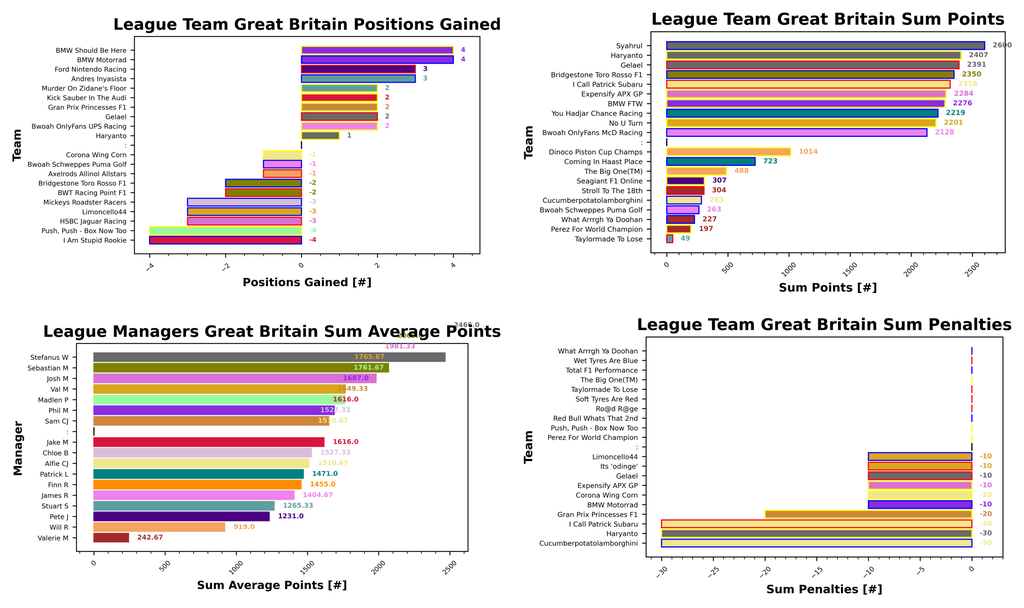

Isack Hadjar continues his run as most popular driver with 33 selections this week. Fernando Alonso holds onto second with 26, ahead of Piastri with 18, Hulkenberg with 17, and Bearman with 16. Yuki Tsunoda and Max Verstappen only make 2 appearance each this week, followed by Kimi Antonelli who makes 3. Lewis Hamilton appears 5 times, with Gasly and Lawson making 6. Lance Stroll rounds out the bottom five with 7 selections.

McLaren lead the way with 17 selections, ahead of Haas with 15 and a trio of Racing Bulls, Kick Sauber, and Ferrari with 11. Red Bull only managed 5, behind Williams, Aston Martin, and Alpine with 6. Mercedes round out the bottom three with 8 selections.

Oscar Piastri continues to be the most boosted driver this week with 17, ahead of teammate Norris with 8, and Leclerc and Doohan at 5 a piece. There was only 1 token this week, and it was a wildcard.

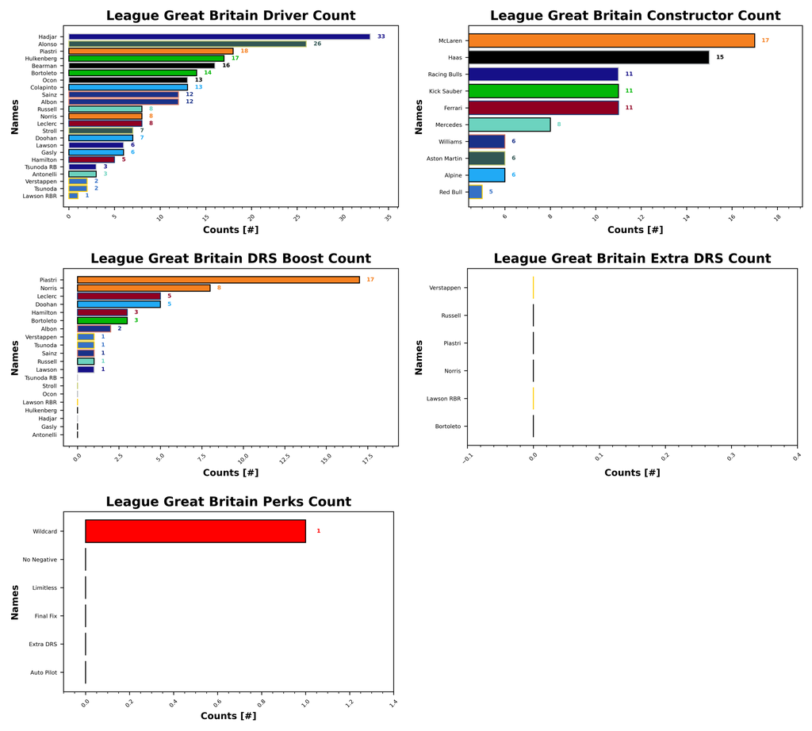

## Prizes

### Championship

| Prize Name | Prize Value | Terms |
| --- | --- | --- |
|  | (%) |  |
| Champion of the World | 20 | Awarded to the top scorer in the league at the end of the season |
| If You're Not First, You're Last | 10 | Awarded to the second place scorer in the league at the end of the season |
| Alpine Podium | 5 | Awarded to the third place scorer in the league at the end of the season |
| Above Par | 20 | Awarded to the lowest scorer in the league at the end of the season, commonly referred to as the Golf League |

### Achievements

| Prize Name | Prize Value | Terms |
| --- | --- | --- |
|  | (%) |  |
| Cost Cappen | 5 | Highest average points per value at the end of the season |
| Sprint King | 5 | Highest score across the sprint races (China, Miami, Belgium, United States, Brazil, Qatar) |
| Flavio Controls Every Millimeter | 5 | Manager wide substitution count, highest wins |
| The Triple Header | 5 | Highest score across the triple header races (Japan, Bahrain, Saudi Arabia, Emilia Romagna, Monaco, Spain, Las Vegas, Qatar, Abu Dhabi) |
| I Forgot I Was Taking Part | 5 | Highest score in the first part of the season |
| Zak's Master Plan | 5 | Lowest score in the second half of the season |
| Mega Driver | 5 | Highest Extra DRS token score |
| The Continental | 5 | Highest score across all 5 continents, Mexico classed as South America for inclusion only (Australia, Canada, Great Britain, Azerbaijan, Mexico) |

### Spot Prizes

| Prize Name | Prize Value | Terms |
| --- | --- | --- |
|  | (%) |  |
| The Ring | 1 | Highest score at the Austrian Grand Prix |
| Bottas Bowling | 1 | Highest score at the Hungarian Grand Prix |
| Daniel's Broken Hand | 1 | Lowest score at the Netherlands Grand Prix |
| The Tifosi | 1 | Lowest score at the Italian Grand Prix |
| Go For The Gap | 1 | Lowest score at the Singapore Grand Prix |

### Cost Cappen

Stefanus tops the higher average points per value at the moment with Syahrul sitting on 2.09 ppm. Patrick and You Hadjar Chance Racing are in second with 2.01, and Sebastian is in third with 2.01 (distinguished by rounding) with Bridgestone Toro Rosso F1.

### Flavio Controls Every Millimeter

Stefanus and Gelael lead the way with 29 substitutions, ahead of Syahrul with 28 and Josh with Expensify APX GP with the same. Josh and Sebastian are tied for third with Kingfisher Force India F1 and BWT Racing Point F1 with 27.

### Mega Driver

Check back later!

### Sprint King

No Change. Sebastian is in the lead with Bridgestone Toro Rosso F1 and 652 points, ahead of Josh with Expensify APX GP and HSBC Jaguar Racing with 622 and 591 points.

### The Continental

Canada was of course part of The Continental prize this year. The standings are currently Sebastian at the top with Bridgestone Toro Rosso F1 and 552 points, ahead of Phil and BMW FTW with 530. Jake is in third with Kick Sauber In The Audi and 527 points.

### The Triple Header

Stefanus is dominating this prize with all three teams. Gelael, from Syahrul and Haryanto, with 1342, 1255 and 1218 points respectively.

### I Forgot I Was Taking Part

I Forgot I Was Taking Part will match up with the current championship standings.

### Zak's Master Plan

Check back after the season break!

## F1 Predict

Stuart took the top step this weekend with 62 points, ahead of Val with 57. Phil ties for second ahead of Josh with 45 points. Pierce and Matty both scored 0.

That means Stuart holds on to the lead with 705 points ahead of Phil with 674, and Val with 644 points. Josh is in fourth place with 570, ahead of Pierce with 248, and Matty with 95.

## Next Up

Next up, Spa Francorchamps, and it's a sprint weekend.... and it's supposed to rain. It could be quite the exciting weekend.